# 作业4

辛柏嬴 2020111753

2023-05-08

## 第一题

*对十项全能运动得分样本相关矩阵进行因子分析*

```r
# load data
path1 <- "/Users/xinby/Desktop/Sufe/Multivariate-Stat-Analysis/Hw&Proj/hw4/exec8.4.xlsx"
dat1 <- read_xlsx(path1) %>% select(-event)

# Factor Analysis with no rotations
print("--------------------------------------------------------------------------------")
print("|                    Factor Analysis with No Rotations:                        |")
print("--------------------------------------------------------------------------------")
factor <- fa( dat1, nfactors = 4, rotate = "none",
              residuals = T, fm='ml') # Maximum Likelihood Factor Analysis
print(factor)

# Factor Analysis with rotations
print("-------------------------------------------------------------------------------")
print("|                Factor Analysis with Max-Variance Rotations:                 |")
print("-------------------------------------------------------------------------------")
factor.maxvar <- fa( dat1, nfactors = 4, rotate = "varimax",
              residuals = T, fm='ml') # Maximum Likelihood Factor Analysis
print(factor.maxvar)
```

```
## [1] "--------------------------------------------------------------------------------"
## [1] "|                    Factor Analysis with No Rotations:                        |"
## [1] "--------------------------------------------------------------------------------"
## Factor Analysis using method =  ml
## Call: fa(r = dat1, nfactors = 4, rotate = "none", residuals = T, fm = "ml")
## Standardized loadings (pattern matrix) based upon correlation matrix
##      ML2   ML3   ML1   ML4   h2    u2 com
## x1  0.21  0.82  0.30 -0.17 0.84 0.159 1.5
## x2  0.38  0.59  0.25  0.27 0.62 0.379 2.6
## x3  0.64 -0.02  0.76  0.00 1.00 0.005 1.9
## x4  0.41  0.33  0.16  0.44 0.50 0.499 3.1
## x5  0.45  0.66 -0.11 -0.14 0.67 0.328 1.9
## x6  0.26  0.42  0.26  0.39 0.46 0.539 3.4
## x7  0.50  0.01  0.54  0.01 0.54 0.462 2.0
## x8  0.31  0.22  0.06  0.39 0.30 0.699 2.6
## x9  0.31 -0.02  0.31  0.09 0.21 0.795 2.2
## x10 0.71 -0.01 -0.70  0.00 1.00 0.005 2.0
##
##                        ML2  ML3  ML1  ML4
## SS loadings           1.98 1.79 1.72 0.63
## Proportion Var        0.20 0.18 0.17 0.06
## Cumulative Var        0.20 0.38 0.55 0.61
## Proportion Explained  0.32 0.29 0.28 0.10
## Cumulative Proportion 0.32 0.62 0.90 1.00
##
## Mean item complexity =  2.3
## Test of the hypothesis that 4 factors are sufficient.
##
## The degrees of freedom for the null model are  45  and the objective function was  3.7
## The degrees of freedom for the model are 11  and the objective function was  0.07
##
## The root mean square of the residuals (RMSR) is  0.02
## The df corrected root mean square of the residuals is  0.04
##
## Fit based upon off diagonal values = 1
## Measures of factor score adequacy
##                                                    ML2  ML3  ML1  ML4
## Correlation of (regression) scores with factors   1.00 0.94 1.00 0.76
## Multiple R square of scores with factors          0.99 0.88 1.00 0.57
## Minimum correlation of possible factor scores     0.99 0.76 0.99 0.15
```

[output cut: 26 more lines]

```
## Mean item complexity =  1.5
## Test of the hypothesis that 4 factors are sufficient.
##
## The degrees of freedom for the null model are  45  and the objective function was  3.7
## The degrees of freedom for the model are 11  and the objective function was  0.07
##
## The root mean square of the residuals (RMSR) is  0.02
## The df corrected root mean square of the residuals is  0.04
##
## Fit based upon off diagonal values = 1
## Measures of factor score adequacy
##                                                    ML1  ML3  ML4  ML2
## Correlation of (regression) scores with factors   0.99 0.91 0.80 1.00
## Multiple R square of scores with factors          0.98 0.82 0.65 0.99
## Minimum correlation of possible factor scores     0.96 0.65 0.29 0.98
```

因子分析结果如上所示。分别展示了不进行旋转和进行了最大方差旋转，以MLE为估计准则的结果。 具体而言，主要的分析结果摘录如下（最大方差旋转结果）：

|  | ML1 | ML3 | ML4 | ML2 | h2 | u2 | com |
| --- | --- | --- | --- | --- | --- | --- | --- |
| x1 | 0.17 | 0.86 | 0.25 | -0.14 | 0.84 | 0.159 | 1.3 |
| x2 | 0.24 | 0.48 | 0.58 | 0.01 | 0.62 | 0.379 | 2.3 |
| x3 | 0.96 | 0.15 | 0.20 | -0.06 | 1.00 | 0.005 | 1.1 |
| x4 | 0.24 | 0.17 | 0.63 | 0.11 | 0.50 | 0.499 | 1.5 |
| x5 | 0.06 | 0.71 | 0.24 | 0.33 | 0.67 | 0.328 | 1.7 |
| x6 | 0.21 | 0.26 | 0.59 | -0.07 | 0.46 | 0.539 | 1.7 |
| x7 | 0.70 | 0.13 | 0.18 | -0.01 | 0.54 | 0.462 | 1.2 |
| x8 | 0.14 | 0.08 | 0.51 | 0.12 | 0.30 | 0.699 | 1.3 |
| x9 | 0.42 | 0.02 | 0.17 | 0.00 | 0.21 | 0.795 | 1.3 |
| x10 | -0.05 | 0.06 | 0.11 | 0.99 | 1.00 | 0.005 | 1.0 |

其中ML1～ML4表示的是最终得到的四个因子。h2表示共性方差，表示的是这些公共因子对各个变量x的方差贡献；u表示特殊方差，表示的是特殊因子对于x的方差贡献。

对于该因子分析，其相应的效果评估为：

|  | ML1 | ML3 | ML4 | ML2 |
| --- | --- | --- | --- | --- |
| SS loadings | 1.80 | 1.61 | 1.58 | 1.14 |
| Proportion Var | 0.18 | 0.16 | 0.16 | 0.11 |
| Cumulative Var | 0.18 | 0.34 | 0.50 | 0.61 |
| Proportion Explained | 0.29 | 0.26 | 0.26 | 0.19 |
| Cumulative Proportion | 0.29 | 0.56 | 0.81 | 1.00 |

其中 Cumulative Var 表示累计方差比例，表示前 n 个因子解释的方差占总方差的比例

## 第二题

*对洛杉矶人口调查进行因子分析；变量1～5分别表示：人口数、教育程度/教育年数中位数、佣人总数、服务业人数、房价中位数。*

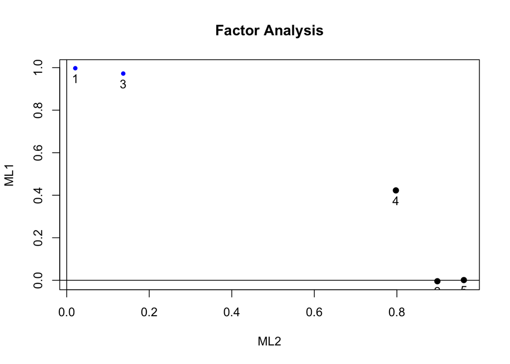

```
## [1] "-------------------------------------------------------------------------------"
## [1] "|                Factor Analysis with Max-Variance Rotations:                 |"
## [1] "-------------------------------------------------------------------------------"
## Factor Analysis using method =  ml
## Call: fa(r = dat2.R, nfactors = 2, rotate = "varimax", residuals = T,
##     fm = "ml")
## Standardized loadings (pattern matrix) based upon correlation matrix
##     ML2  ML1   h2    u2 com
## X1 0.02 1.00 1.00 0.005 1.0
## X2 0.90 0.00 0.81 0.193 1.0
## X3 0.14 0.97 0.96 0.036 1.0
## X4 0.80 0.42 0.81 0.185 1.5
## X5 0.96 0.00 0.93 0.074 1.0
##
##                        ML2  ML1
## SS loadings           2.39 2.12
## Proportion Var        0.48 0.42
## Cumulative Var        0.48 0.90
## Proportion Explained  0.53 0.47
## Cumulative Proportion 0.53 1.00
##
## Mean item complexity =  1.1
## Test of the hypothesis that 2 factors are sufficient.
##
## The degrees of freedom for the null model are  10  and the objective function was  6.38
## The degrees of freedom for the model are 1  and the objective function was  0.31
##
## The root mean square of the residuals (RMSR) is  0.01
## The df corrected root mean square of the residuals is  0.05
##
## Fit based upon off diagonal values = 1
## Measures of factor score adequacy
##                                                    ML2  ML1
## Correlation of (regression) scores with factors   0.98 1.00
## Multiple R square of scores with factors          0.95 1.00
## Minimum correlation of possible factor scores     0.91 0.99
```

```r
# load data
path2 <- "/Users/xinby/Desktop/Sufe/Multivariate-Stat-Analysis/Hw&Proj/hw4/exec8.5.xlsx"
dat2 <- read_xlsx(path2) %>% select(-i)
dat2.R <- cor(dat2)

# Factor Analysis with rotations
print("-------------------------------------------------------------------------------")
print("|                Factor Analysis with Max-Variance Rotations:                 |")
print("-------------------------------------------------------------------------------")
factor.ny<- fa( dat2.R , nfactors = 2, rotate = "varimax",
                residuals = T, fm='ml') # Maximum Likelihood Factor Analysis

print(factor.ny)
plot(factor.ny)
```

因子分析结果如上所示，其中对应因子载荷为：

|  | ML2 | ML1 | h2 | u2 | com |
| --- | --- | --- | --- | --- | --- |
| X1 | 0.02 | 1.00 | 1.00 | 0.005 | 1.0 |
| X2 | 0.90 | 0.00 | 0.81 | 0.193 | 1.0 |
| X3 | 0.14 | 0.97 | 0.96 | 0.036 | 1.0 |
| X4 | 0.80 | 0.42 | 0.81 | 0.185 | 1.5 |
| X5 | 0.96 | 0.00 | 0.93 | 0.074 | 1.0 |

对应的因子分析效果为：

|  | ML2 | ML1 |
| --- | --- | --- |
| SS loadings | 2.39 | 2.12 |
| Proportion Var | 0.48 | 0.42 |
| Cumulative Var | 0.48 | 0.90 |
| Proportion Explained | 0.53 | 0.47 |
| Cumulative Proportion | 0.53 | 1.00 |

根据实际情况对比，大约可以认为ML2表示的是有关社会生产条件、生活条件等方面相关，ML1主要与地区人口状况相关.

## 第三题

*对应征者15个方面的得分进行因子分析*

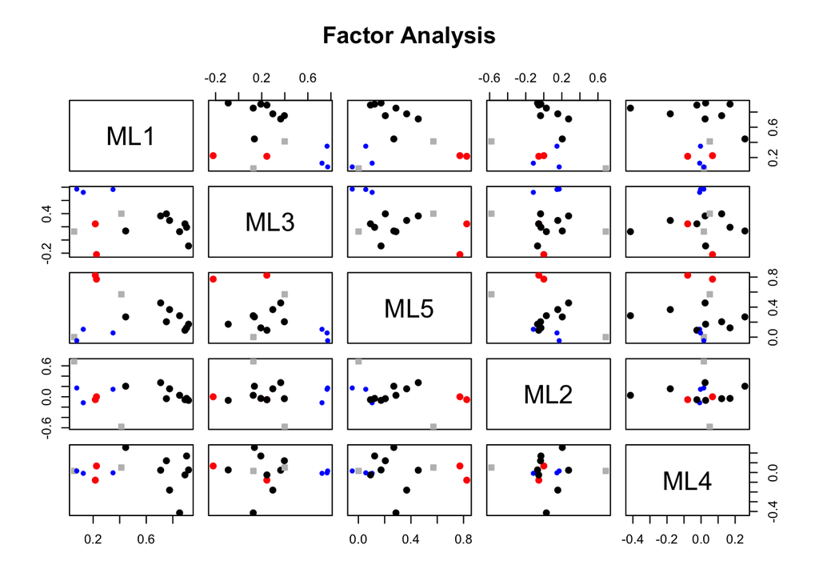

```
## [1] "-------------------------------------------------------------------------------"
## [1] "|                Factor Analysis with Max-Variance Rotations:                 |"
## [1] "-------------------------------------------------------------------------------"
## Factor Analysis using method =  ml
## Call: fa(r = dat3.R, nfactors = 5, rotate = "varimax", residuals = T,
##     fm = "ml")
## Standardized loadings (pattern matrix) based upon correlation matrix
##      ML1   ML3   ML5   ML2   ML4   h2    u2 com
## x1  0.13  0.72  0.10 -0.12 -0.01 0.56 0.438 1.2
## x2  0.45  0.14  0.27  0.20  0.26 0.40 0.602 3.1
## x3  0.06  0.13  0.00  0.69  0.02 0.49 0.508 1.1
## x4  0.22  0.24  0.82 -0.06 -0.08 0.80 0.205 1.4
## x5  0.92 -0.09  0.17 -0.07  0.03 0.89 0.113 1.1
## x6  0.85  0.13  0.29  0.03 -0.41 1.00 0.005 1.8
## x7  0.23 -0.22  0.77  0.00  0.07 0.70 0.300 1.4
## x8  0.89  0.25  0.09 -0.06 -0.02 0.87 0.133 1.2
## x9  0.08  0.77 -0.05  0.17  0.02 0.63 0.367 1.1
## x10 0.75  0.40  0.20 -0.04  0.12 0.78 0.220 1.8
## x11 0.90  0.19  0.12 -0.03  0.17 0.90 0.101 1.2
## x12 0.78  0.30  0.37  0.15 -0.18 0.88 0.119 2.0
## x13 0.71  0.36  0.46  0.27  0.02 0.92 0.082 2.6
## x14 0.41  0.40  0.57 -0.58  0.05 1.00 0.005 3.6
## x15 0.35  0.77  0.06  0.15  0.00 0.73 0.266 1.5
##
##                        ML1  ML3  ML5  ML2  ML4
## SS loadings           5.46 2.51 2.21 1.03 0.33
## Proportion Var        0.36 0.17 0.15 0.07 0.02
## Cumulative Var        0.36 0.53 0.68 0.75 0.77
## Proportion Explained  0.47 0.22 0.19 0.09 0.03
## Cumulative Proportion 0.47 0.69 0.88 0.97 1.00
##
## Mean item complexity =  1.7
## Test of the hypothesis that 5 factors are sufficient.
##
## The degrees of freedom for the null model are  105  and the objective function was  15.75
## The degrees of freedom for the model are 40  and the objective function was  1.66
##
## The root mean square of the residuals (RMSR) is  0.03
## The df corrected root mean square of the residuals is  0.05
##
## Fit based upon off diagonal values = 1
## Measures of factor score adequacy
##                                                    ML1  ML3  ML5  ML2  ML4
## Correlation of (regression) scores with factors   0.98 0.94 0.94 0.96 0.95
## Multiple R square of scores with factors          0.96 0.88 0.88 0.93 0.89
## Minimum correlation of possible factor scores     0.93 0.76 0.77 0.85 0.79
```

```r
# load data
path3 <- "/Users/xinby/Desktop/Sufe/Multivariate-Stat-Analysis/Hw&Proj/hw4/exec8.6.xlsx"
dat3 <- read_xlsx(path3) %>% select(-i)
dat3.R <- cor(dat3)

# Factor Analysis with rotations
print("-------------------------------------------------------------------------------")
print("|                Factor Analysis with Max-Variance Rotations:                 |")
print("-------------------------------------------------------------------------------")
factor.app<- fa( dat3.R , nfactors = 5, rotate = "varimax",
                residuals = T, fm='ml') # Maximum Likelihood Factor Analysis

print(factor.app)

plot(factor.app)
```

因子分析结果如下：

|  | ML1 | ML3 | ML5 | ML2 | ML4 | h2 | u2 | com |
| --- | --- | --- | --- | --- | --- | --- | --- | --- |
| x1 | 0.13 | 0.72 | 0.10 | -0.12 | -0.01 | 0.56 | 0.438 | 1.2 |
| x2 | 0.45 | 0.14 | 0.27 | 0.20 | 0.26 | 0.40 | 0.602 | 3.1 |
| x3 | 0.06 | 0.13 | 0.00 | 0.69 | 0.02 | 0.49 | 0.508 | 1.1 |
| x4 | 0.22 | 0.24 | 0.82 | -0.06 | -0.08 | 0.80 | 0.205 | 1.4 |
| x5 | 0.92 | -0.09 | 0.17 | -0.07 | 0.03 | 0.89 | 0.113 | 1.1 |
| x6 | 0.85 | 0.13 | 0.29 | 0.03 | -0.41 | 1.00 | 0.005 | 1.8 |
| x7 | 0.23 | -0.22 | 0.77 | 0.00 | 0.07 | 0.70 | 0.300 | 1.4 |
| x8 | 0.89 | 0.25 | 0.09 | -0.06 | -0.02 | 0.87 | 0.133 | 1.2 |
| x9 | 0.08 | 0.77 | -0.05 | 0.17 | 0.02 | 0.63 | 0.367 | 1.1 |
| x10 | 0.75 | 0.40 | 0.20 | -0.04 | 0.12 | 0.78 | 0.220 | 1.8 |
| x11 | 0.90 | 0.19 | 0.12 | -0.03 | 0.17 | 0.90 | 0.101 | 1.2 |
| x12 | 0.78 | 0.30 | 0.37 | 0.15 | -0.18 | 0.88 | 0.119 | 2.0 |
| x13 | 0.71 | 0.36 | 0.46 | 0.27 | 0.02 | 0.92 | 0.082 | 2.6 |
| x14 | 0.41 | 0.40 | 0.57 | -0.58 | 0.05 | 1.00 | 0.005 | 3.6 |
| x15 | 0.35 | 0.77 | 0.06 | 0.15 | 0.00 | 0.73 | 0.266 | 1.5 |

|  | ML1 | ML3 | ML5 | ML2 | ML4 |
| --- | --- | --- | --- | --- | --- |
| SS loadings | 5.46 | 2.51 | 2.21 | 1.03 | 0.33 |
| Proportion Var | 0.36 | 0.17 | 0.15 | 0.07 | 0.02 |
| Cumulative Var | 0.36 | 0.53 | 0.68 | 0.75 | 0.77 |
| Proportion Explained | 0.47 | 0.22 | 0.19 | 0.09 | 0.03 |
| Cumulative Proportion | 0.47 | 0.69 | 0.88 | 0.97 | 1.00 |

结合各项的具体含义，ML1主要体现了应征者的能力、进取心，ML3主要体现了应征者的相关经验，ML5主要体现了应征者的人际关系等，ML2主要体现了应征者的专业能力，ML4主要反映了应征者的外在形象等。